# R Notebook

```r
library(readr)
library(MASS)
reviews <- read.csv("~/Desktop/lab3estaca/LasVegasTripAdvisorReviews-Dataset.csv", sep=";")
```

Se elige como muestra para analizar los scores de USA y Canada

```r
scores_USA <- subset(reviews, User.country == "USA")
scores_canada <- subset(reviews, User.country == "Canada")
```

Se presenta a continuación una tabla con las medias, medianas y desviación estandar de ambos subconjuntos.

```r
tabla <- matrix(c(mean(scores_USA$Score, na.rm = TRUE), var(scores_USA$Score, na.rm = TRUE), sd(scores_USA$Score, na.rm = TRUE), median(scores_USA$Score, na.rm = TRUE), mean(scores_canada$Score, na.rm = TRUE), var(scores_canada$Score, na.rm = TRUE), sd(scores_canada$Score, na.rm = TRUE), median(scores_canada$Score, na.rm = TRUE)), ncol = 4, byrow = TRUE)
colnames(tabla) <- c("Media", "Varianza", "Des_Estandar", "Mediana")
rownames(tabla) <- c("USA", "Canada")
tabla <- as.table(tabla)
tabla
```

```
          Media Varianza Des_Estandar  Mediana
USA    4.156682 1.030893     1.015329 4.000000
Canada 4.107692 1.191346     1.091488 4.000000
```

Se puede ver que en general ambos paises aparentan tener valores similares en cada comparación, la media tiene una diferencia de 0,05 unidades aproximadamente, mientras que la varianza es de 0,16 unidades (es la mayor diferencia apreciable para estos valores), la desviación estandar posee una diferencia de 0,08 y la mediana es igual para ambos casos.

Se puede desprender de esta información dos posibilidades, la primera, en general el publico estado unidense califica su estadia en los hoteles mejor que Canada, la segunda la cantidad de votantes estado unidenses es mucho mayor que la de Canada lo que permite una mejor diferenciación en medias.

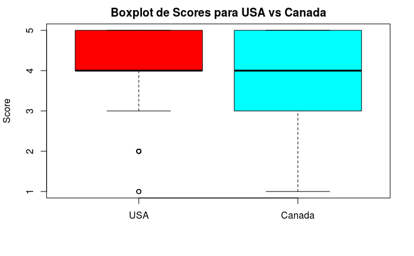

```r
boxplot(scores_USA$Score, scores_canada$Score, names = c("USA", "Canada"), col = rainbow(2), ylab = "Score", main = "Boxplot de Scores para USA vs Canada")
```

Notar que el segundo cuartil de cada caso se encuentra casi a la misma altura, en general se puede ver que la apreciación de los norteamericanos es mayor que la de los canadienses los cuales tienen una opinion mas variada, tal como se nombro anteriormente.

Se pueden ver un par de valores extremos (outliers) dentro del boxplot de USA, se puede concluir que en muy pocas ocaciones USA califica mal sus propios hoteles.

2. Se determinan los 10 paises con mayor cantidad de reviews.

```r
x2 <- aggregate(reviews$Nr..reviews, by=list(reviews$User.country), FUN=sum)
x2 <- x2[order(-x2$x), ][1:10, ]
x2
```

|  | Group.1 | x |
| --- | --- | --- |
| 48 | USA | 12419 |
| 46 | UK | 3186 |
| 4 | Canada | 2128 |
| 1 | Australia | 1256 |
| 13 | Germany | 385 |
| 30 | Mexico | 376 |
| 18 | India | 349 |
| 36 | Saudi Arabia | 320 |
| 21 | Ireland | 314 |
| 31 | Netherlands | 312 |

Se realiza el barplot.

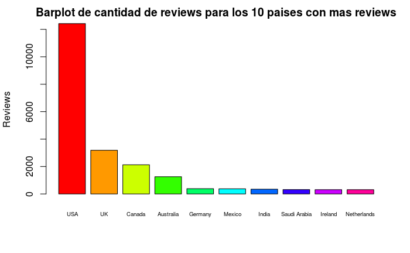

```r
barplot(c(12419, 3186, 2128, 1256, 385, 376, 349, 320, 314, 312), main = "Barplot de cantidad de reviews para los 10 paises con mas reviews", col = rainbow(10), names = c("USA", "UK", "Canada", "Australia", "Germany", "Mexico", "India", "Saudi Arabia", "Ireland", "Netherlands"), ylab = "Reviews", cex.names = 0.6)
```

Haciendo referencia a los comentarios anteriores, se puede confirmar gracias a este gráfico que la cantidad de ciudadanos de USA que se hospedan en las vegas es mucho mayor que los de otros paises.

Se procede a calcular el intervalo de confianza de la media. Para intervalos de confianza de 90, 95 y 99% respectivamente:

```r
t.test(reviews$Nr..rooms, conf.level = 0.90)
```

```
    One Sample t-test

data:  reviews$Nr..rooms
t = 38.358, df = 503, p-value < 2.2e-16
alternative hypothesis: true mean is not equal to 0
90 percent confidence interval:
 2102.023 2290.739
sample estimates:
mean of x
 2196.381
```

```r
t.test(reviews$Nr..rooms, conf.level = 0.95)
```

```
    One Sample t-test

data:  reviews$Nr..rooms
t = 38.358, df = 503, p-value < 2.2e-16
alternative hypothesis: true mean is not equal to 0
95 percent confidence interval:
 2083.883 2308.879
sample estimates:
mean of x
 2196.381
```

```r
t.test(reviews$Nr..rooms, conf.level = 0.99)
```

```
    One Sample t-test

data:  reviews$Nr..rooms
t = 38.358, df = 503, p-value < 2.2e-16
alternative hypothesis: true mean is not equal to 0
99 percent confidence interval:
 2048.328 2344.434
sample estimates:
mean of x
 2196.381
```

Donde se observan los intervalos de confianza como se indica: Con 90% de confianza: [2102.023, 2290.739] Con 95% de confianza: [2083.883, 2308.879] Con 99% de confianza: [2048.328, 2344.434]

Con valor de media muestral igual a 2196.381.

```r
chisq.test(reviews$Nr..rooms, reviews$Score)
```

```
Chi-squared approximation may be incorrect
```

```
    Pearson's Chi-squared test

data:  reviews$Nr..rooms and reviews$Score
X-squared = 140.34, df = 80, p-value = 3.575e-05
```

H0 -> los factores son independientes H1 -> Los factores no son independientes

```r
wilcox.test(reviews$Nr..rooms, reviews$Score)
```

```
    Wilcoxon rank sum test with continuity correction

data:  reviews$Nr..rooms and reviews$Score
W = 254020, p-value < 2.2e-16
alternative hypothesis: true location shift is not equal to 0
```

H0 -> las muestras tienen igual distribución H1 -> las muestras tienen distribución distintas

```r
#datos <- subset(reviews, Member.years >= 0)
#data <- hist(datos$Member.years, col = rainbow(10), main = "alo", prob = TRUE)
USA <- subset(reviews, User.country == "USA" & Member.years >= 0)
#hist(USA$Member.years, col = rainbow(10), main = "Histograma de los años de miembros", xlab = "Rango de Edades", ylab = "Cantidad", prob = TRUE)
#lines(density(USA$Member.years))
#histo
mediana = 0
media = 0
varianza = 0
for(i in 1:1000){
  muestra <- sample(USA$Member.years, size=200)
  media = media + mean(muestra)
  mediana = mediana + median(muestra)
  varianza = varianza + var(muestra)
}
mediana = mediana / 1000
media = media / 1000
varianza = varianza / 1000
mediana
```

```
[1] 4
```

```r
media
```

```
[1] 4.4946
```

```r
varianza
```

```
[1] 9.559035
```

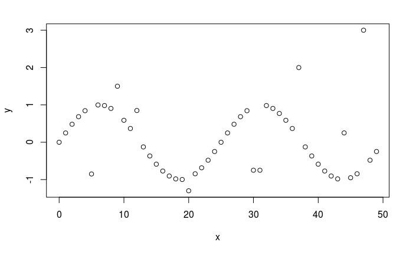

```r
load("sinewave.RData")
plot(dirtywave)
```

[output not shown]

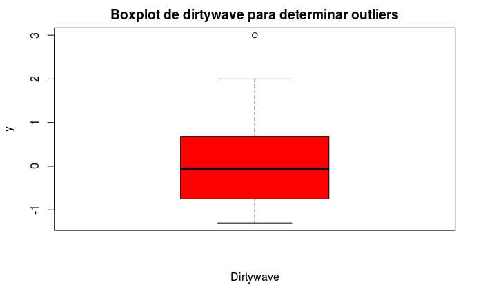

```r
boxplot(dirtywave$y, col = rainbow(1), main = "Boxplot de dirtywave para determinar outliers", ylab = "y", xlab = "Dirtywave")
```

```
Se puede notar un valor extremo sobre el bigote superior el cual se encuentra cercano al valor 3, al ser un valor muy distinto del rango común de la función se reemplazara el outlier con la media.
```

```r
media <- mean(dirtywave$y)
outlier.replace(dirtywave$y, alpha = 0.05, value = media)
```

```
Error: could not find function "outlier.replace"
```

[output not shown]